# KOICA 사업별 SDGs 연계 현황

2주차

Author

최요한

Published

May 29, 2026

**Note**

🛠️ 핵심 패키지

#R 데이터분석의 핵심 패키지 “tidyverse”  
xlsx (엑셀) 파일을 불러오는데 사용되는 패키지 “readxl”  
테이블(표)를 예쁘게 그릴 때 사용되는 패키지 “gt”

**tidyverse 패키지 로드 Code**

```r
library(tidyverse)            # 라이브러리 로드
```

**gt 패키지 설치 Code**

```r
install.packages("gt")        # 표 생성 패키지
library(gt)                   # 라이브러리 로드
```

**readxl 패키지 설치 Code**

```r
install.packages("readxl")    # xlsx 파일 불러오기
library(readxl)               # 라이브러리 로드
```

# 1 자료 출처

🔗 출처: [공공데이터포탈](https://www.data.go.kr/data/15121333/fileData.do)

[figure not shown]

> 데이터 샘플

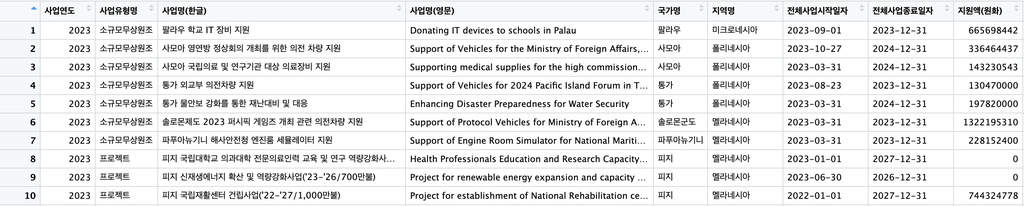

SDGs 연계현황 엑셀 다운로드

## 1.1 xlsx 파일 불러오기

**패키지 설치**

“readxl 패키지 설치 Code”를 완료했다면 생략하세요

1.Packages

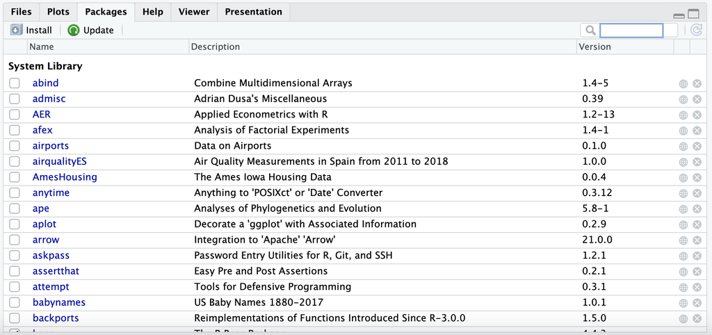

2.readxl “입력” -> Install “클릭”

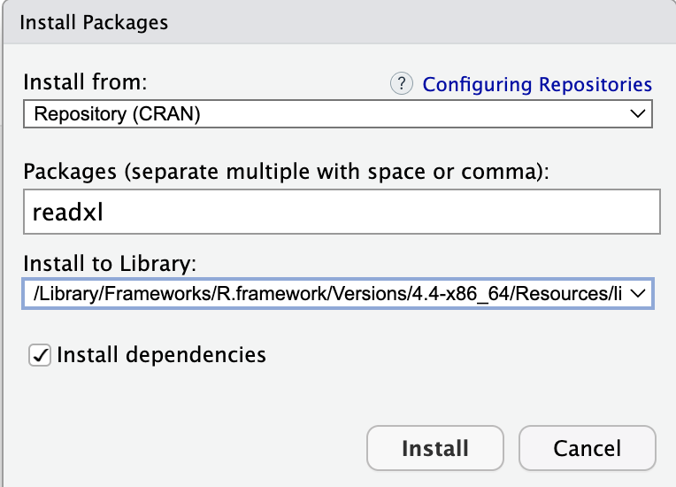

**엑셀파일 불러오기**

1.Environment

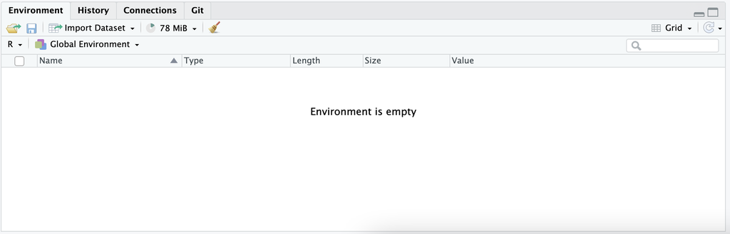

2.Import Dataset > From Excel…

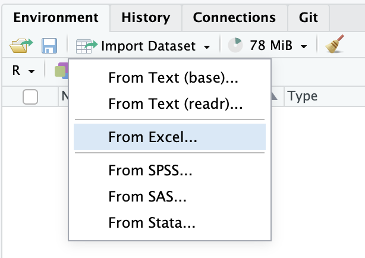

3.Browse

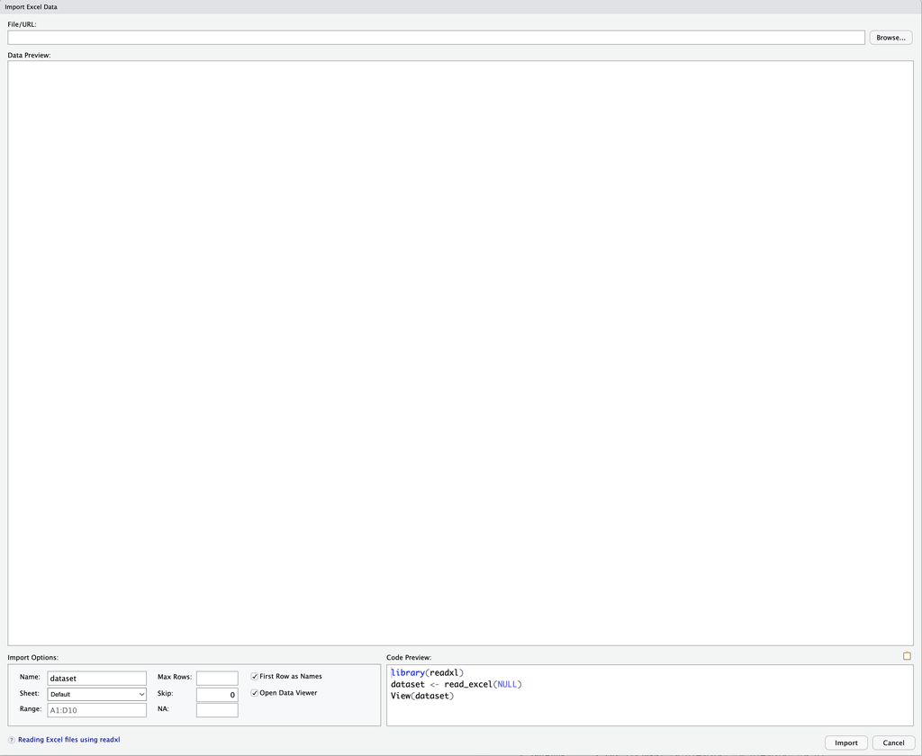

4.파일 선택

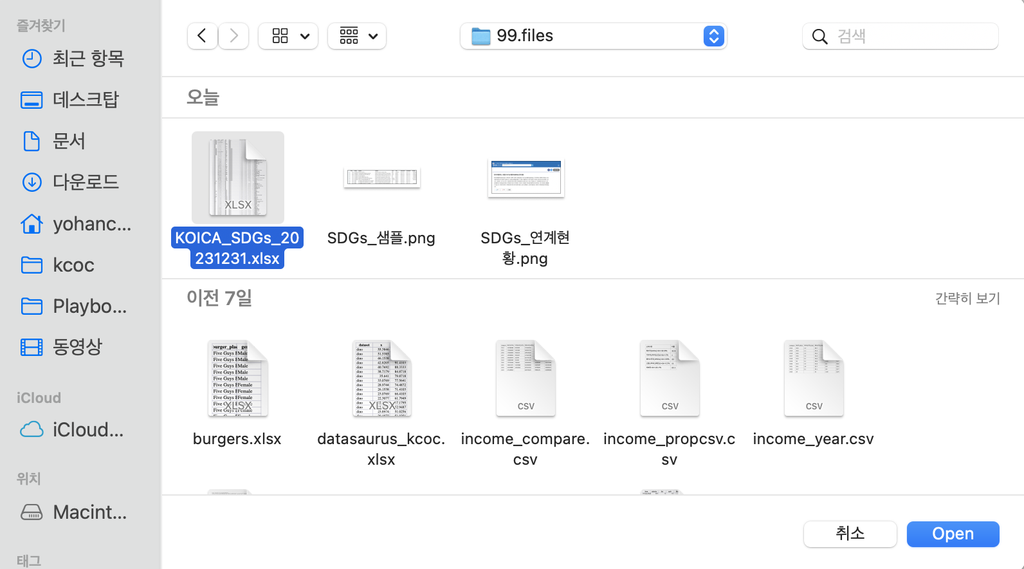

5.Import

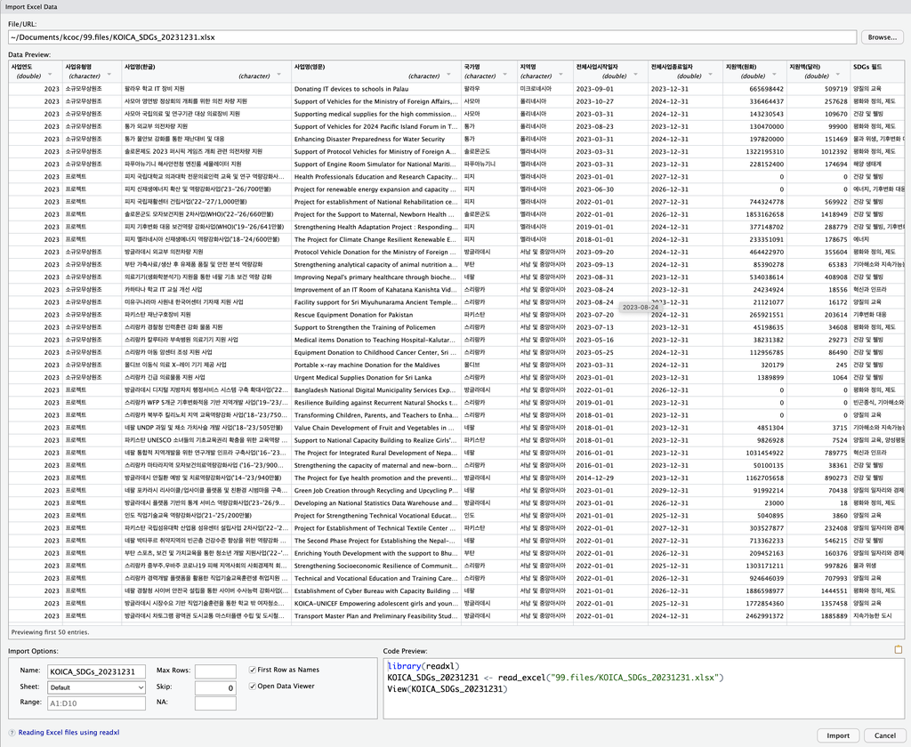

6.(참고) 1~5 과정은 아래 코드와 동일함

```r
# library(readxl)
# KOICA_SDGs_20231231 <- read_excel("엑셀파일.xlsx")
```

### 1.1.1 변수에 저장하기

> 변수명: KOICA_SDGs_20231231

```r
read_xlsx("../../99.files/KOICA_SDGs_20231231.xlsx") ->  KOICA_SDGs_20231231

print(KOICA_SDGs_20231231)
```

```
# A tibble: 2,860 × 11
   사업연도 사업유형명     `사업명(한글)`           `사업명(영문)` 국가명 지역명
      <dbl> <chr>          <chr>                    <chr>          <chr>  <chr>
 1     2023 소규모무상원조 팔라우 학교 IT 장비 지원 Donating IT d… 팔라우 미크로네시…
 2     2023 소규모무상원조 사모아 영연방 정상회의 개최를 위한 의전 … Support of Ve… 사모아 폴리네시아…
 3     2023 소규모무상원조 사모아 국립의료 및 연구기관 대상 의료장비… Supporting me… 사모아 폴리네시아…
 4     2023 소규모무상원조 통가 외교부 의전차량 지원…… Support of Ve… 통가   폴리네시아…
 5     2023 소규모무상원조 통가 물안보 강화를 통한 재난대비 및 대응… Enhancing Dis… 통가   폴리네시아…
 6     2023 소규모무상원조 솔로몬제도 2023 퍼시픽 게임즈 개최 관… Support of Pr… 솔로몬군도… 멜라네시아…
 7     2023 소규모무상원조 파푸아뉴기니 해사안전청 엔진룸 세뮬레이터 … Support of En… 파푸아뉴기… 멜라네시아…
 8     2023 프로젝트       피지 국립대학교 의과대학 전문의료인력 교육… Health Profes… 피지   멜라네시아…
 9     2023 프로젝트       피지 신재생에너지 확산 및 역량강화사업('… Project for r… 피지   멜라네시아…
10     2023 프로젝트       피지 국립재활센터 건립사업('22-'27/… Project for e… 피지   멜라네시아…
# ℹ 2,850 more rows
# ℹ 5 more variables: 전체사업시작일자 <dttm>, 전체사업종료일자 <dttm>,
#   `지원액(원화)` <dbl>, `지원액(달러)` <dbl>, `SDGs 필드` <chr>
```

# 2 데이터셋 구조

## 2.1 용어 정의

> 데이터는 “데이터프레임”, “변수(열)”, “관측치(행)”, “값(셀)”로 구분합니다.

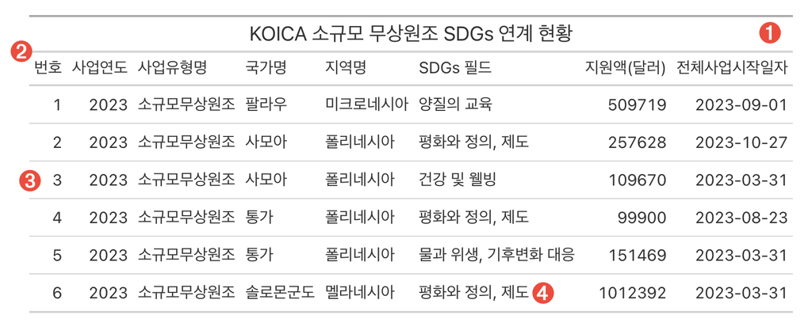

1. 데이터 프레임(시트): “KOICA 소규모 무상원조 SDGs 연계 현황” 전체 표
2. 변수(열): ‘번호’,‘사업연도’, ‘사업유형명’ 등을 의미 (세로열)
3. 관측치(행): 1, 2023, 소규모무상원조, 사모아 등 한 행을 의미 (가로줄)
4. 값(셀): ‘폴리네시아’, ’양질의 교육’와 같은 하나의 값을 의미

**펼쳐보기**

```r
KOICA_SDGs_20231231 |>
  select(사업연도, 사업유형명, 국가명, 지역명, `SDGs 필드`,
         `지원액(달러)`, 전체사업시작일자) |>
  mutate(번호 = row_number(), .before = 1) |>
  head() |>
  gt::gt() |>
  gt::tab_header(
    title = ("KOICA 소규모 무상원조 SDGs 연계 현황")
    )
```

KOICA 소규모 무상원조 SDGs 연계 현황

| 번호 | 사업연도 | 사업유형명 | 국가명 | 지역명 | SDGs 필드 | 지원액(달러) | 전체사업시작일자 |
| --- | --- | --- | --- | --- | --- | --- | --- |
| 1 | 2023 | 소규모무상원조 | 팔라우 | 미크로네시아 | 양질의 교육 | 509719 | 2023-09-01 |
| 2 | 2023 | 소규모무상원조 | 사모아 | 폴리네시아 | 평화와 정의, 제도 | 257628 | 2023-10-27 |
| 3 | 2023 | 소규모무상원조 | 사모아 | 폴리네시아 | 건강 및 웰빙 | 109670 | 2023-03-31 |
| 4 | 2023 | 소규모무상원조 | 통가 | 폴리네시아 | 평화와 정의, 제도 | 99900 | 2023-08-23 |
| 5 | 2023 | 소규모무상원조 | 통가 | 폴리네시아 | 물과 위생, 기후변화 대응 | 151469 | 2023-03-31 |
| 6 | 2023 | 소규모무상원조 | 솔로몬군도 | 멜라네시아 | 평화와 정의, 제도 | 1012392 | 2023-03-31 |

## 2.2 데이터 보기

> 데이터 셋의 형식과 종류, 크기 등을 알수 있습니다.

```r
KOICA_SDGs_20231231
```

```
# A tibble: 2,860 × 11
   사업연도 사업유형명     `사업명(한글)`           `사업명(영문)` 국가명 지역명
      <dbl> <chr>          <chr>                    <chr>          <chr>  <chr>
 1     2023 소규모무상원조 팔라우 학교 IT 장비 지원 Donating IT d… 팔라우 미크로네시…
 2     2023 소규모무상원조 사모아 영연방 정상회의 개최를 위한 의전 … Support of Ve… 사모아 폴리네시아…
 3     2023 소규모무상원조 사모아 국립의료 및 연구기관 대상 의료장비… Supporting me… 사모아 폴리네시아…
 4     2023 소규모무상원조 통가 외교부 의전차량 지원…… Support of Ve… 통가   폴리네시아…
 5     2023 소규모무상원조 통가 물안보 강화를 통한 재난대비 및 대응… Enhancing Dis… 통가   폴리네시아…
 6     2023 소규모무상원조 솔로몬제도 2023 퍼시픽 게임즈 개최 관… Support of Pr… 솔로몬군도… 멜라네시아…
 7     2023 소규모무상원조 파푸아뉴기니 해사안전청 엔진룸 세뮬레이터 … Support of En… 파푸아뉴기… 멜라네시아…
 8     2023 프로젝트       피지 국립대학교 의과대학 전문의료인력 교육… Health Profes… 피지   멜라네시아…
 9     2023 프로젝트       피지 신재생에너지 확산 및 역량강화사업('… Project for r… 피지   멜라네시아…
10     2023 프로젝트       피지 국립재활센터 건립사업('22-'27/… Project for e… 피지   멜라네시아…
# ℹ 2,850 more rows
# ℹ 5 more variables: 전체사업시작일자 <dttm>, 전체사업종료일자 <dttm>,
#   `지원액(원화)` <dbl>, `지원액(달러)` <dbl>, `SDGs 필드` <chr>
```

```r
# 참고
Titanic
Titanic |> str()
```

[output not shown]

## 2.3 데이터 펼쳐보기

#### view()

> 엑셀의 격자표처럼 한번에 펼쳐보는 함수입니다.

```r
KOICA_SDGs_20231231 |>
  view()
```

## 2.4 데이터 크기

#### dim()

> 데이터가 몇개의 변수와 몇 줄의 관측치로 구성되어 있는지를 의미합니다.

```r
KOICA_SDGs_20231231 |>
  dim()
```

```
[1] 2860   11
```

## 2.5 데이터 구성

### 2.5.1 glimpse()

> 변수의 종류가 ‘문자’, ‘숫자’, ‘범주’ 등 무엇인지 확인합니다

> > 첫번째 변수명은 무엇입니까?

> > 열번째 변수명은 무엇입니까?

```r
KOICA_SDGs_20231231 |>
  glimpse()
```

```
Rows: 2,860
Columns: 11
$ 사업연도         <dbl> 2023, 2023, 2023, 2023, 2023, 2023, 2023, 2023, 2023,…
$ 사업유형명       <chr> "소규모무상원조", "소규모무상원조", "소규모무상원조", "소규모무상원조", "소규모무상원조"…
$ `사업명(한글)`   <chr> "팔라우 학교 IT 장비 지원", "사모아 영연방 정상회의 개최를 위한 의전 차량 지원", "사…
$ `사업명(영문)`   <chr> "Donating IT devices to schools in Palau", "Support o…
$ 국가명           <chr> "팔라우", "사모아", "사모아", "통가", "통가", "솔로몬군도", "파푸아뉴기니", "…
$ 지역명           <chr> "미크로네시아", "폴리네시아", "폴리네시아", "폴리네시아", "폴리네시아", "멜라네시아"…
$ 전체사업시작일자 <dttm> 2023-09-01, 2023-10-27, 2023-03-31, 2023-08-23, 2023…
$ 전체사업종료일자 <dttm> 2023-12-31, 2024-12-31, 2024-12-31, 2023-12-31, 2024…
$ `지원액(원화)`   <dbl> 665698442, 336464437, 143230543, 130470000, 197820000…
$ `지원액(달러)`   <dbl> 509719, 257628, 109670, 99900, 151469, 1012392, 17469…
$ `SDGs 필드`      <chr> "양질의 교육", "평화와 정의, 제도", "건강 및 웰빙", "평화와 정의, 제도", "물과 …
```

### 2.5.2 str()

> 사업연도는 ‘숫자형’, ‘문자형’, ‘시간형’ 중 무엇입니까?

> 전체사업시작일자는 ‘숫자형’, ‘문자형’, ‘시간형’ 중 무엇입니까?

> SDGs 필드는 ‘숫자형’, ‘문자형’, ‘시간형’ 중 무엇입니까?

```r
KOICA_SDGs_20231231 |>
  str()
```

```
tibble [2,860 × 11] (S3: tbl_df/tbl/data.frame)
 $ 사업연도        : num [1:2860] 2023 2023 2023 2023 2023 ...
 $ 사업유형명      : chr [1:2860] "소규모무상원조" "소규모무상원조" "소규모무상원조" "소규모무상원조" ...
 $ 사업명(한글)    : chr [1:2860] "팔라우 학교 IT 장비 지원" "사모아 영연방 정상회의 개최를 위한 의전 차량 지원" "사모아 국립의료 및 연구기관 대상 의료장비 지원" "통가 외교부 의전차량 지원" ...
 $ 사업명(영문)    : chr [1:2860] "Donating IT devices to schools in Palau" "Support of Vehicles for the Ministry of Foreign Affairs, Samoa" "Supporting medical supplies for the high commission of the Independent State of Samoa in Wellington" "Support of Vehicles for 2024 Pacific Island Forum in Tonga" .…
 $ 국가명          : chr [1:2860] "팔라우" "사모아" "사모아" "통가" ...
 $ 지역명          : chr [1:2860] "미크로네시아" "폴리네시아" "폴리네시아" "폴리네시아" ...
 $ 전체사업시작일자: POSIXct[1:2860], format: "2023-09-01" "2023-10-27" ...
 $ 전체사업종료일자: POSIXct[1:2860], format: "2023-12-31" "2024-12-31" ...
 $ 지원액(원화)    : num [1:2860] 6.66e+08 3.36e+08 1.43e+08 1.30e+08 1.98e+08 ...
 $ 지원액(달러)    : num [1:2860] 509719 257628 109670 99900 151469 ...
 $ SDGs 필드       : chr [1:2860] "양질의 교육" "평화와 정의, 제도" "건강 및 웰빙" "평화와 정의, 제도" ...
```

## 2.6 데이터 수치 요약

#### summary()

> 숫자형 데이터의 평균, 최솟값, 최댓값을 한번에 확인하는 함수

```r
KOICA_SDGs_20231231 |>
  summary()
```

```
    사업연도     사업유형명        사업명(한글)       사업명(영문)
 Min.   :2023   Length:2860        Length:2860        Length:2860
 1st Qu.:2023   Class :character   Class :character   Class :character
 Median :2023   Mode  :character   Mode  :character   Mode  :character
 Mean   :2023
 3rd Qu.:2023
 Max.   :2023
    국가명             지역명          전체사업시작일자
 Length:2860        Length:2860        Min.   :2011-01-01 00:00:00.00
 Class :character   Class :character   1st Qu.:2021-11-25 12:00:00.00
 Mode  :character   Mode  :character   Median :2023-01-01 00:00:00.00
                                       Mean   :2022-05-13 16:47:29.78
                                       3rd Qu.:2023-01-01 00:00:00.00
                                       Max.   :2023-12-31 00:00:00.00
 전체사업종료일자                 지원액(원화)        지원액(달러)
 Min.   :2023-01-30 00:00:00.0   Min.   :0.000e+00   Min.   :       0
 1st Qu.:2023-12-31 00:00:00.0   1st Qu.:8.513e+06   1st Qu.:    6519
 Median :2023-12-31 00:00:00.0   Median :4.117e+07   Median :   31527
 Mean   :2024-09-28 11:29:17.2   Mean   :3.342e+08   Mean   :  255915
 3rd Qu.:2024-12-31 00:00:00.0   3rd Qu.:2.322e+08   3rd Qu.:  177821
 Max.   :2030-12-31 00:00:00.0   Max.   :8.998e+10   Max.   :68893778
  SDGs 필드
 Length:2860
 Class :character
 Mode  :character
```

# 3 데이터 가공

## 3.1 표 만들기

### 3.1.1 count()

> 특정 변수를 기준으로 표를 만들수 있습니다

```r
KOICA_SDGs_20231231 |>
  count(사업유형명)
```

```
# A tibble: 10 × 2
   사업유형명           n
   <chr>            <int>
 1 개발인식증진         1
 2 개발컨설팅          17
 3 국제기구협력사업    59
 4 민관협력사업       227
 5 봉사단             582
 6 소규모무상원조     164
 7 연수생초청사업    1372
 8 인도적지원          17
 9 프로젝트           420
10 행정성경비           1
```

### 3.1.2 연습문제

> A. 지역명을 기준으로 표를 만드세요

```r
KOICA_SDGs_20231231 |>
  count(지역명)
```

```
# A tibble: 20 × 2
   지역명                 n
   <chr>              <int>
 1 그외                  23
 2 극동 아시아          778
 3 남부아프리카          13
 4 남아메리카           249
 5 동부아프리카         517
 6 멜라네시아            52
 7 미크로네시아           6
 8 사하라 이남            1
 9 사하라 이북          107
10 서남 및 중앙아시아   494
11 서부아프리카         237
12 아메리카 지역          2
13 아시아 지역            4
14 아프리카 지역          3
15 유럽                  23
16 중동                  80
17 중부아프리카         135
18 중앙 아메리카         87
19 카리브해              42
20 폴리네시아             7
```

```r
KOICA_SDGs_20231231 |>
  count(국가명)
```

```
# A tibble: 130 × 2
   국가명                               n
   <chr>                            <int>
 1 가나                                83
 2 가이아나                             1
 3 감비아                               2
 4 과테말라                            20
 5 그레나다                             3
 6 그외 지역 또는 다수국가 (미배분)    23
 7 기니                                 3
 8 기니비사우                           2
 9 나미비아                             1
10 나이지리아                          58
# ℹ 120 more rows
```

```r
KOICA_SDGs_20231231 |>
  count('SDG 필드')
```

```
# A tibble: 1 × 2
  `"SDG 필드"`     n
  <chr>        <int>
1 SDG 필드      2860
```

## 3.2 고유값 확인

#### unique()

> SDGs 필드에는 총 몇개의 목표가 연결되어 있나요?

```r
unique(KOICA_SDGs_20231231$'SDGs 필드')
```

[output not shown]

# 4 탐색적 데이터 분석

## 4.1 최댓값 확인

#### slice_max()

> 지원액(달러)를 기준으로 가장 많은 예산이 지원된 사업 10개를 출력합니다

```r
KOICA_SDGs_20231231 |>
  slice_max(order_by = `지원액(달러)`, n = 10)
```

```
# A tibble: 10 × 11
   사업연도 사업유형명   `사업명(한글)`             `사업명(영문)` 국가명 지역명
      <dbl> <chr>        <chr>                      <chr>          <chr>  <chr>
 1     2023 행정성경비   행정성경비                 2023 Administ… 그외 지역… 그외
 2     2023 개발인식증진 개발인식증진               Development A… 그외 지역… 그외
 3     2023 프로젝트     이라크 중환자 전문의료 서비스 역량강화사업('… The Project f… 이라크 중동
 4     2023 프로젝트     아시아태평양지역 예비조사, 기획조사, 사후관리… Feasibility s… 아시아 국… 아시아 지…
 5     2023 인도적지원   2023-2024 튀르키예 임시 정착촌 조성 … Building and … 터키   유럽
 6     2023 봉사단       개발인식 증진  관련 영프로페셔널(국내) 파견… Young Profess… 그외 지역… 그외
 7     2023 프로젝트     베트남 뚜옌꽝성 포용적 농촌개발 프로그램(`1… Rural Develop… 베트남 극동 아시…
 8     2023 프로젝트     몽골 국립과학수사원 법과학 역량강화 사업('2… The Project o… 몽골   극동 아시…
 9     2023 프로젝트     에티오피아 오로미아-소말리주 분쟁지역 이주민 … IOM Project f… 에티오피아… 동부아프리…
10     2023 프로젝트     탄자니아 보건분야 공동재정지원 프로그램 3차사… Tanzania Heal… 탄자니아…… 동부아프리…
# ℹ 5 more variables: 전체사업시작일자 <dttm>, 전체사업종료일자 <dttm>,
#   `지원액(원화)` <dbl>, `지원액(달러)` <dbl>, `SDGs 필드` <chr>
```

## 4.2 최솟값 확인

#### slice_min()

```r
KOICA_SDGs_20231231 |>
  slice_min(order_by = `지원액(달러)`, n = 10)
```

```
# A tibble: 48 × 11
   사업연도 사업유형명 `사업명(한글)`               `사업명(영문)` 국가명 지역명
      <dbl> <chr>      <chr>                        <chr>          <chr>  <chr>
 1     2023 프로젝트   피지 국립대학교 의과대학 전문의료인력 교육 및 연… Health Profes… 피지   멜라네시아…
 2     2023 프로젝트   피지 신재생에너지 확산 및 역량강화사업('23-'… Project for r… 피지   멜라네시아…
 3     2023 프로젝트   방글라데시 디지털 지방자치 행정서비스 시스템 구축… Bangladesh Na… 방글라데시… 서남 및 …
 4     2023 프로젝트   스리랑카 WFP 5개군 기후변화적응 기반 지역개발… Resilience Bu… 스리랑카…… 서남 및 …
 5     2023 프로젝트   스리랑카 북부주 킬리노치 지역 교육역량강화 사업(… Transforming … 스리랑카…… 서남 및 …
 6     2023 프로젝트   몽골 UNICEF 지역사회기반 기후변화대응 WAS… Community-bas… 몽골   극동 아시…
 7     2023 개발컨설팅 몽골 직업기술교육훈련(TVET) 시스템 개선사업(… Partnership b… 몽골   극동 아시…
 8     2023 프로젝트   인도네시아 유료도로 운영정보시스템 구축사업(`23… The Estalishm… 인도네시아… 극동 아시…
 9     2023 프로젝트   인도네시아 재난대응 공공의료 훈련 역량강화사업('… Capacity Buil… 인도네시아… 극동 아시…
10     2023 프로젝트   필리핀 UNESCO 타클로반 지역 학교밖 소녀를 … Better Life f… 필리핀 극동 아시…
# ℹ 38 more rows
# ℹ 5 more variables: 전체사업시작일자 <dttm>, 전체사업종료일자 <dttm>,
#   `지원액(원화)` <dbl>, `지원액(달러)` <dbl>, `SDGs 필드` <chr>
```

## 4.3 사업시작일자의 분포

#### geom_histogram()

> 사업시작일자의 분포(밀집된 정도)를 살펴봅니다

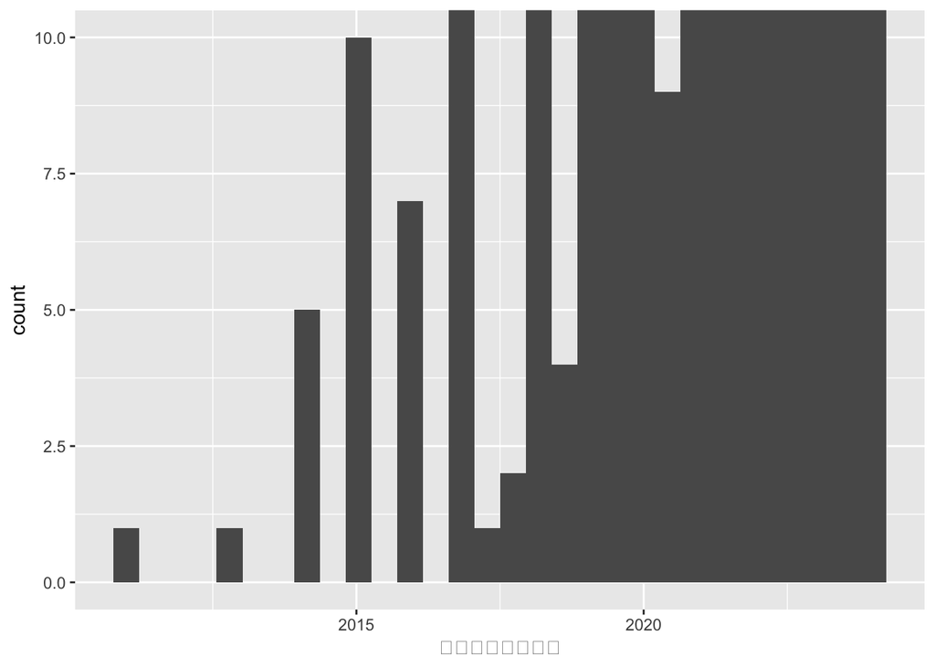

```r
ggplot(KOICA_SDGs_20231231,
       aes(x = 전체사업시작일자)) +
  geom_histogram() +
  coord_cartesian(ylim = c(0,10))
```

### 4.3.1 연습문제

> A.전체사업종료일자의 분포(밀집된 정도)를 시각화하세요

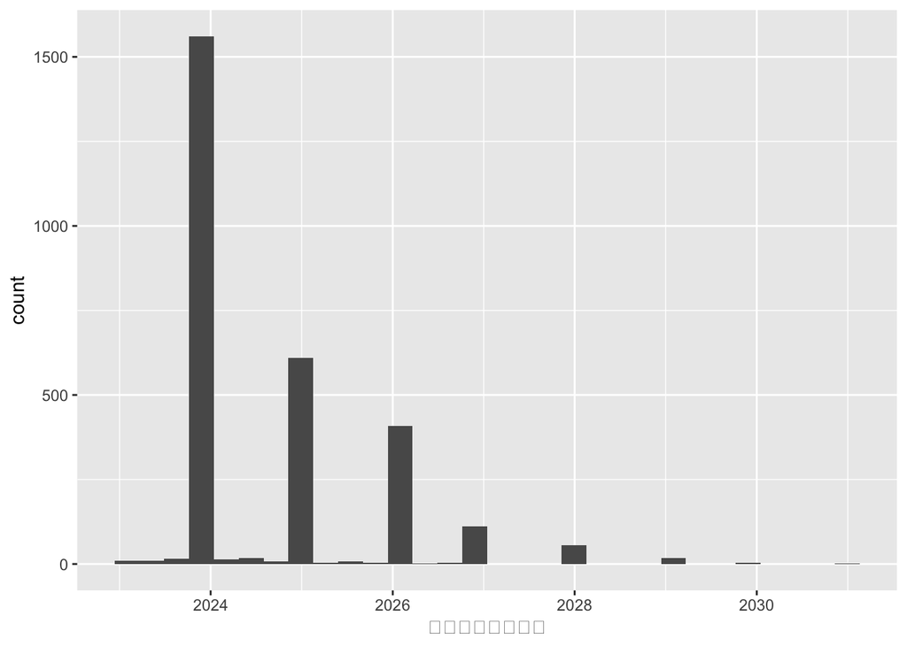

```r
ggplot(KOICA_SDGs_20231231,
       aes(x = 전체사업종료일자)) +
  geom_histogram()
```

> 가장 빠른 ’전체사업시작일자’는 몇년도 몇월 몇일인가요?

```r
KOICA_SDGs_20231231 |>
  slice_min(전체사업시작일자)
```

```
# A tibble: 1 × 11
  사업연도 사업유형명 `사업명(한글)`                `사업명(영문)` 국가명 지역명
     <dbl> <chr>      <chr>                         <chr>          <chr>  <chr>
1     2023 프로젝트   볼리비아 추키사카주 저수용댐 축조 및 관개수로 건설… Irrigation of… 볼리비아…… 남아메리카…
# ℹ 5 more variables: 전체사업시작일자 <dttm>, 전체사업종료일자 <dttm>,
#   `지원액(원화)` <dbl>, `지원액(달러)` <dbl>, `SDGs 필드` <chr>
```

# 5 penguins 연습문제

palmerpenguins 데이터셋을 설치합니다.

```r
if(!require(palmerpenguins))install.packages("palmerpenguins")
library(palmerpenguins)
penguins
```

```
# A tibble: 344 × 8
   species island    bill_length_mm bill_depth_mm flipper_length_mm body_mass_g
   <fct>   <fct>              <dbl>         <dbl>             <int>       <int>
 1 Adelie  Torgersen           39.1          18.7               181        3750
 2 Adelie  Torgersen           39.5          17.4               186        3800
 3 Adelie  Torgersen           40.3          18                 195        3250
 4 Adelie  Torgersen           NA            NA                  NA          NA
 5 Adelie  Torgersen           36.7          19.3               193        3450
 6 Adelie  Torgersen           39.3          20.6               190        3650
 7 Adelie  Torgersen           38.9          17.8               181        3625
 8 Adelie  Torgersen           39.2          19.6               195        4675
 9 Adelie  Torgersen           34.1          18.1               193        3475
10 Adelie  Torgersen           42            20.2               190        4250
# ℹ 334 more rows
# ℹ 2 more variables: sex <fct>, year <int>
```

> 1. penguins 데이터셋은 몇 행, 몇 열입니까?
>    1. penguins 데이터셋은 몇 개의 변수로 되어 있습니까?
>    2. penguins 데이터셋은 몇 줄로 되어 있습니까?
> 2. 아래 변수들은 각각 무엇을 의미합니까?
>    1. bill_length_mm
>    2. bill_depth_mm
>    3. species
>    4. island
>    5. flipper_length_mm
>    6. body_mass_g
>    7. sex
>    8. year
> 3. x축 bill_length_mm, y축 bill_depth_mm으로 하는 산점도(geom_point)를 그리시오
> 4. 위 그래프를 penguins_kcoc 변수에 넣으시오
> 5. penguins_kcoc 변수에 `+ facet_wrap(.~species)` 를 추가하시오

>    `penguins_kcoc + facet_warp(.~species)`